# STA 138 Final Project

Connor Young

12/6/2023

### Load Data

```r
byss = read.csv("./Dataset/Byssinosis.csv")
head(byss)
```

```
##   Employment Smoking Sex Race Workspace Byssinosis Non.Byssinosis
## 1        <10     Yes   M    W         1          3             37
## 2        <10     Yes   M    O         1         25            139
## 3        <10     Yes   F    W         1          0              5
## 4        <10     Yes   F    O         1          2             22
## 5        <10      No   M    W         1          0             16
## 6        <10      No   M    O         1          6             75
```

```r
# change Workspace to factor
byss$Workspace = factor(byss$Workspace, levels = c("3", "2", "1"))
```

```r
# add Total column equal to Byssinosis + Non.Byssinosis
byss$Total = byss$Byssinosis + byss$Non.Byssinosis
```

```r
# remove rows which have no total
byss = byss[byss$Total!=0,]
```

```r
# unique values of each predictor variable
sapply(byss[1:5], function(x) unique(x))
```

```
## $Employment
## [1] "<10"   "10-19" ">=20"
##
## $Smoking
## [1] "Yes" "No"
##
## $Sex
## [1] "M" "F"
##
## $Race
## [1] "W" "O"
##
## $Workspace
## [1] 1 2 3
## Levels: 3 2 1
```

### Logistic Regression Models

#### All Additive Terms and No Interctions

```r
glm1 = glm(cbind(Byssinosis, Non.Byssinosis)~Employment + Smoking + Sex + Race + Workspace,
           family=binomial(),
           data=byss)
summary(glm1)
```

```
##
## Call:
## glm(formula = cbind(Byssinosis, Non.Byssinosis) ~ Employment +
##     Smoking + Sex + Race + Workspace, family = binomial(), data = byss)
##
## Deviance Residuals:
##     Min       1Q   Median       3Q      Max
## -1.5076  -0.8218  -0.2693   0.2879   1.5709
##
## Coefficients:
##                 Estimate Std. Error z value Pr(>|z|)
## (Intercept)      -5.1028     0.2643 -19.308  < 2e-16 ***
## Employment>=20    0.7444     0.2169   3.432 0.000600 ***
## Employment10-19   0.5678     0.2619   2.168 0.030177 *
## SmokingYes        0.6709     0.1961   3.421 0.000625 ***
## SexM             -0.1503     0.2296  -0.655 0.512777
## RaceW            -0.1176     0.2077  -0.566 0.571270
## Workspace2        0.1713     0.2870   0.597 0.550546
## Workspace1        2.7617     0.2172  12.713  < 2e-16 ***
## ---
## Signif. codes:  0 '***' 0.001 '**' 0.01 '*' 0.05 '.' 0.1 ' ' 1
##
## (Dispersion parameter for binomial family taken to be 1)
##
##     Null deviance: 324.114  on 64  degrees of freedom
## Residual deviance:  42.679  on 57  degrees of freedom
## AIC: 164.98
##
## Number of Fisher Scoring iterations: 5
```

```r
BIC(glm1)
```

```
## [1] 182.3771
```

```r
confint.default(glm1)
```

```
##                       2.5 %     97.5 %
## (Intercept)     -5.62081192 -4.5848382
## Employment>=20   0.31923027  1.1695809
## Employment10-19  0.05443102  1.0812555
## SmokingYes       0.28650604  1.0553657
## SexM            -0.60034204  0.2997582
## RaceW           -0.52467718  0.2894865
## Workspace2      -0.39121682  0.7338872
## Workspace1       2.33596023  3.1874919
```

#### Forward Step-Wise Regression

```r
result1 = step(glm(cbind(Byssinosis, Non.Byssinosis)~1, binomial(), byss),
                  scope = ~Employment*Smoking*Sex*Race*Workspace,
                  k=log(72),
                  trace=0,
                  direction="forward")
summary(result1)
```

```
##
## Call:
## glm(formula = cbind(Byssinosis, Non.Byssinosis) ~ Workspace +
##     Smoking + Employment, family = binomial(), data = byss)
##
## Deviance Residuals:
##     Min       1Q   Median       3Q      Max
## -1.6131  -0.8065  -0.2514   0.3084   1.6743
##
## Coefficients:
##                 Estimate Std. Error z value Pr(>|z|)
## (Intercept)      -5.2077     0.2375 -21.931  < 2e-16 ***
## Workspace2        0.1925     0.2852   0.675 0.499666
## Workspace1        2.7393     0.1914  14.315  < 2e-16 ***
## SmokingYes        0.6464     0.1925   3.358 0.000786 ***
## Employment>=20    0.6596     0.1820   3.625 0.000289 ***
## Employment10-19   0.5055     0.2492   2.029 0.042508 *
## ---
## Signif. codes:  0 '***' 0.001 '**' 0.01 '*' 0.05 '.' 0.1 ' ' 1
##
## (Dispersion parameter for binomial family taken to be 1)
##
##     Null deviance: 324.114  on 64  degrees of freedom
## Residual deviance:  43.429  on 59  degrees of freedom
## AIC: 161.73
##
## Number of Fisher Scoring iterations: 5
```

```r
BIC(result1)
```

```
## [1] 174.779
```

```r
confint.default(result1)
```

```
##                       2.5 %     97.5 %
## (Intercept)     -5.67315243 -4.7423365
## Workspace2      -0.36641854  0.7513960
## Workspace1       2.36420684  3.1143267
## SmokingYes       0.26909047  1.0236948
## Employment>=20   0.30292282  1.0161852
## Employment10-19  0.01708115  0.9938192
```

#### Compare the Two Models w/ Likelihood Ratio Test

```r
# H_0: models are equivalent -> use simpler model
# H_1: models are not equivalent -> use more complex model
anv = anova(result1, glm1)
pvalue = 1-pchisq(anv[2, 4], anv[2,3])
pvalue
```

```
## [1] 0.6870723
```

#### Variable Modifications

```r
# changing Workplace var
# 2 & 3 -> 3 (less dusty)
# 1 -> 1 (more dusty)
byss2 = byss
byss2$Workspace[byss2$Workspace == 2] = 3
```

```r
# new stepwise w/ Workplace modification
new1 = step(glm(cbind(Byssinosis, Non.Byssinosis)~1, binomial(), byss2),
                  scope = ~Employment*Smoking*Sex*Race*Workspace,
                  k=log(72),
                  trace=0,
                  direction="forward")
summary(new1)
```

```
##
## Call:
## glm(formula = cbind(Byssinosis, Non.Byssinosis) ~ Workspace +
##     Smoking + Employment, family = binomial(), data = byss2)
##
## Deviance Residuals:
##     Min       1Q   Median       3Q      Max
## -1.6156  -0.7821  -0.2584   0.3073   1.8354
##
## Coefficients:
##                 Estimate Std. Error z value Pr(>|z|)
## (Intercept)      -5.1495     0.2190 -23.516  < 2e-16 ***
## Workspace1        2.6842     0.1704  15.749  < 2e-16 ***
## SmokingYes        0.6445     0.1925   3.349 0.000812 ***
## Employment>=20    0.6571     0.1819   3.612 0.000304 ***
## Employment10-19   0.5007     0.2490   2.011 0.044352 *
## ---
## Signif. codes:  0 '***' 0.001 '**' 0.01 '*' 0.05 '.' 0.1 ' ' 1
##
## (Dispersion parameter for binomial family taken to be 1)
##
##     Null deviance: 324.114  on 64  degrees of freedom
## Residual deviance:  43.874  on 60  degrees of freedom
## AIC: 160.18
##
## Number of Fisher Scoring iterations: 5
```

```r
BIC(new1)
```

```
## [1] 171.0489
```

```r
confint.default(new1)
```

```
##                       2.5 %     97.5 %
## (Intercept)     -5.57871322 -4.7203201
## Workspace1       2.35019087  3.0182868
## SmokingYes       0.26727387  1.0217511
## Employment>=20   0.30050913  1.0136781
## Employment10-19  0.01264627  0.9888278
```

```r
1-pchisq(anova(new1, result1)[2, 4], anova(new1, result1)[2,3]) # compare new1 & result1 w/ LRT
```

```
## [1] 0.5050566
```

```r
# changing Employment var
# 10-19 & >=20 -> >=10
byss2$Employment[byss2$Employment == "10-19" | byss2$Employment == ">=20"] = ">=10"
```

```r
# new stepwise w/ Employment modification
new2 = step(glm(cbind(Byssinosis, Non.Byssinosis)~1, binomial(), byss2),
                  scope = ~Employment*Smoking*Sex*Race*Workspace,
                  k=log(72),
                  trace=0,
                  direction="forward")
summary(new2)
```

```
##
## Call:
## glm(formula = cbind(Byssinosis, Non.Byssinosis) ~ Workspace +
##     Employment + Smoking, family = binomial(), data = byss2)
##
## Deviance Residuals:
##     Min       1Q   Median       3Q      Max
## -1.7071  -0.8030  -0.2876   0.3195   1.8273
##
## Coefficients:
##                Estimate Std. Error z value Pr(>|z|)
## (Intercept)     -5.1427     0.2185 -23.538  < 2e-16 ***
## Workspace1       2.6829     0.1704  15.746  < 2e-16 ***
## Employment>=10   0.6148     0.1704   3.607  0.00031 ***
## SmokingYes       0.6364     0.1920   3.314  0.00092 ***
## ---
## Signif. codes:  0 '***' 0.001 '**' 0.01 '*' 0.05 '.' 0.1 ' ' 1
##
## (Dispersion parameter for binomial family taken to be 1)
##
##     Null deviance: 324.114  on 64  degrees of freedom
## Residual deviance:  44.288  on 61  degrees of freedom
## AIC: 158.59
##
## Number of Fisher Scoring iterations: 5
```

```r
BIC(new2)
```

```
## [1] 167.289
```

```r
confint.default(new2)
```

```
##                     2.5 %     97.5 %
## (Intercept)    -5.5708797 -4.7144360
## Workspace1      2.3489479  3.0168555
## Employment>=10  0.2807494  0.9488551
## SmokingYes      0.2600059  1.0128046
```

```r
1-pchisq(anova(new2, result1)[2, 4], anova(new2, result1)[2,3]) # compare new2 & result1 w/ LRT
```

```
## [1] 0.650914
```

```r
1-pchisq(anova(new2, new1)[2, 4], anova(new2, new1)[2,3]) # compare new2 & new1 w/ LRT
```

```
## [1] 0.5197143
```

#### Logistic Regression Diagnostics

To determine how well our model fits the data, we will look at its deviance residuals. A residual is a measure of the difference between an observed value and a predicted value. The most basic residual for our models is the raw difference between the observed value (Byssinosis status: $y_i \in \{0, 1\}$) and the predicted probability ($\hat{\pi_i} \in [0,1]$). This residual will be denoted as $e_i$ and has the form
$$e_i = y_i - \hat{\pi_i} \in [-1, 1].$$
The deviance residual, $d_i$, is based on deviance which is derived from a likelihood ratio test comparing the fitted logistic model and a *saturated* model which fits each data point perfectly. The formula to calculate the deviance residuals is
$$\begin{aligned}
d_i &= \text{sign}(e_i)\sqrt{\text{Deviance}} \\
&= \text{sign}(e_i) \sqrt{-2 \left[ y_i\log\hat{\pi_i} +
(1-y_i)\log(1-\hat{\pi_i}) \right]}.
\end{aligned}$$

The values of these deviance residuals measure how much the predicted probabilities from our model differ from the observed data and whether our model is under- or over-fitting for certain predictor variable values.

Large values for deviance residuals indicate poor fit and small values indicate good fit. A positive deviance residual indicates our model is under-predicting for a certain set of predictor variable values, i.e., the observed value is 1 and the predicted probability is less than 1. A negative deviance residual indicates our model is over-predicting for a certain set of predictor variable values, i.e., the observed value is 0 and the predicted probability is greater than 0.

A good model fit is indicated by deviance residuals which are evenly distributed and relatively close to 0. Thus, if a smooth line is drawn to “average” the deviance residuals, we would like this line to be relatively flat and close to the line at $d_i=0$.

The plot and interpretation of the deviance residuals for our logistic regression model is shown below.

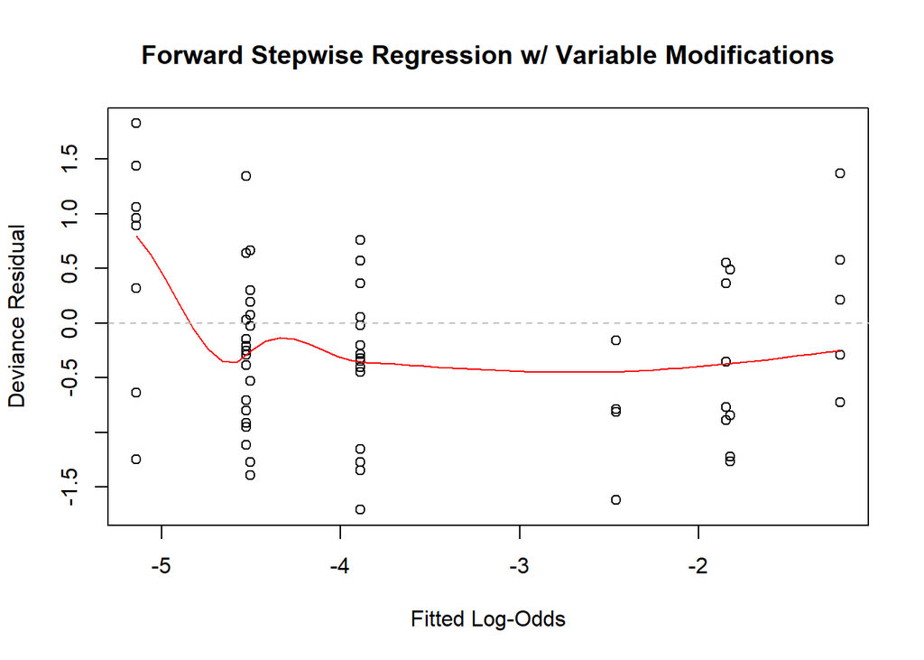

```r
# new2
ry = residuals(new2, type="deviance")
rx = qlogis(fitted.values(new2))

plot(rx, ry,
     xlab = "Fitted Log-Odds",
     ylab = "Deviance Residual",
     main = "Forward Stepwise Regression w/ Variable Modifications",
     col = "black")
lines(loess.smooth(rx, ry), col="red")
abline(h=0, lty=2, col="grey")
```